# Homework 1 - answers

Almog Angel

01/12/2024

In the following tasks you will use statistics and sequence alignment to analyze real COVID-19 world data.

- Load packages

```r
library(tidyverse)
if (!require("BiocManager", quietly = TRUE))
    install.packages("BiocManager")

BiocManager::install("Biostrings")
library(Biostrings)
BiocManager::install("msa")
library(msa)
library(msaR)
library(seqinr)
library(ape)
```

- Set your working directory

```r
# Enter your code here:
path <- getwd()
setwd(path)
```

## Task 1 - Data cleaning

- Read “COVID19_line_list_data.csv” into a variable called “covid_data”

```r
# Enter your code here:
covid_data <- read.csv("COVID19_line_list_data.csv")
```

- Take a look at the data

```r
View(covid_data)
```

- Find a way to remove empty columns:

```r
# Enter your code here:
covid_data %>%
          discard(~all(is.na(.) | . =="")) -> covid_data
```

- Find a way to deal with missing values (NAs) in “age” and “gender” columns

```r
# Enter your code here:
covid_data %>%
           drop_na(.,c(age,gender)) -> covid_data
```

- Assuming ‘death’ is a binary variable (0 for no, 1 for yes) that represent categorical data
- Convert ‘death’ to a factor class that contains either “yes” or “no”

```r
# Enter your code here:
covid_data$death  %>%
                  factor(., levels = c(0,1), labels = c("no", "yes"))-> covid_data$death

covid_data$death[is.na(covid_data$death)] <- "yes"
```

## Task 2 - Descriptive statistics analysis

- Print a descriptive summary of “age”

```r
# Enter your code here:
summary(covid_data$age)
```

```
##    Min. 1st Qu.  Median    Mean 3rd Qu.    Max.
##    0.50   35.00   51.00   49.76   64.00   96.00
```

- Distribution:
- 1. Generate histogram for “age” distribution and color the bars by “death”
- Use: position = ‘identity’, bins = 50, alpha = 0.5

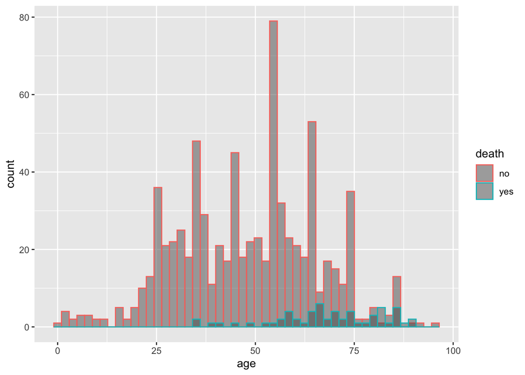

```r
# Enter your code here:
covid_data %>%
          ggplot(., aes(x=age, color=death)) +
          geom_histogram(position = 'identity', bins = 50, alpha = 0.5)
```

- 2. Generate bar plot that visualize the number of dead and alive per gender

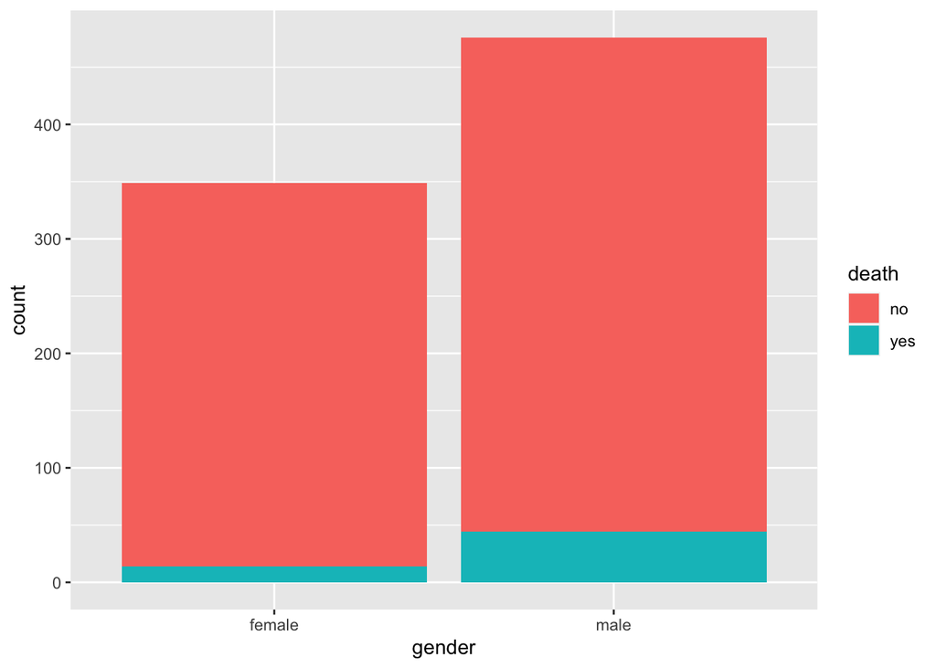

```r
# Enter your code here:
covid_data %>%
          ggplot(., aes(x=gender, fill=death)) +
          geom_bar()
```

```r
tasd=table(covid_data$gender, covid_data$death)
prop.table(tasd, margin = 1)
```

```
##
##                  no        yes
##   female 0.95988539 0.04011461
##   male   0.90756303 0.09243697
```

## Task 3 - Statistical Testing

- Run Chi-squared test to investigate the association between gender and death

```r
# Enter your code here:
chisq.test(x=covid_data$gender, y=covid_data$death)
```

```
##
##  Pearson's Chi-squared test with Yates' continuity correction
##
## data:  covid_data$gender and covid_data$death
## X-squared = 7.6526, df = 1, p-value = 0.005669
```

- Why do we use Chi-squared and not t-test?

```
Type your answer here:
the two variables are categorical rather than numerical.
```

- Define the Null Hypothesis of the Chi-squared Test in this example

```
Type your answer here:
H_0: gender has no effect on mortality due to covid.
```

- What is the p-value? Is it significant (alpha = 0.05)? Write your conclusions from the statistical test results.

```
Type your answer here:
p-value is the probability to get correlation at least as big as we got, given H_0 is true.
the p-value is 0.0057, smaller than alpha = 0.05, thus we reject H_0.
in other words - there is a statistical basis to suspect gender has an effect on morality.
```

According to the media, older people are more likely to die from COVID-19. - Test this claim statistically - Frame your null and alternative hypothesis here:

```
My null hypothesis:
H_0: age has no correlation with mortality due to covid.
My alternative hypothesis:
age has a correlation on mortality due to covid.
```

- Check if the assumption of normality is valid for your data (use alpha of 0.05)

```r
# Enter your code here:
shapiro.test(covid_data$age)
```

```
##
##  Shapiro-Wilk normality test
##
## data:  covid_data$age
## W = 0.98917, p-value = 8.916e-06
```

- Run a statistical test:
- If you assume normality -> use t-test
- else -> use Wilcoxon rank-sum test

```r
# Enter your code here:
wilcox.test(covid_data$age[covid_data$death == "no"], covid_data$age[covid_data$death == "yes"])
```

```
##
##  Wilcoxon rank sum test with continuity correction
##
## data:  covid_data$age[covid_data$death == "no"] and covid_data$age[covid_data$death == "yes"]
## W = 7923.5, p-value = 2.648e-16
## alternative hypothesis: true location shift is not equal to 0
```

- Report the p-value. Is it significant? Write your conclusions from the statistical test results.

```
Type your answer here:
p-value = 2.6e-16, it is very small and hence very significant.
we can safely reject H_0 and claim that the alternative hypothesis holds:
age has a correlation with mortality due to covid.
```

- Read “owid-covid-data.csv” from “https://covid.ourworldindata.org/data/owid-covid-data.csv” into a variable called “covid_world”

```r
# Enter your code here:
covid_world <- read.csv("https://covid.ourworldindata.org/data/owid-covid-data.csv")
```

- Take a look at the data

```r
View(covid_world)
```

Your friend suggest that countries with high Human Development Index (HDI) have a greater risk to die from COVID-19

- Make a second table and call it “covid_hdi_vs_deaths”:
  1. Select rows with “date” equal to “2024-01-21”
  2. Select the following columns: “location”, “human_development_index”, “population”, “total_deaths”
  3. Remove rows with NAs
  4. Calculate the total deaths per million people to a column named “total_deaths_per_million” (round the number)

```r
# Enter your code here:
 covid_world %>%
            subset(., date == "2024-01-21") %>%
            select(.,location, human_development_index, population, total_deaths) %>%
            drop_na(.,) -> covid_hdi_vs_deaths

covid_hdi_vs_deaths$total_deaths_per_million <- round(1e6*covid_hdi_vs_deaths$total_deaths/covid_hdi_vs_deaths$population)
```

- Use a scatterplot to visualize the relations between HDI and the total deaths per million

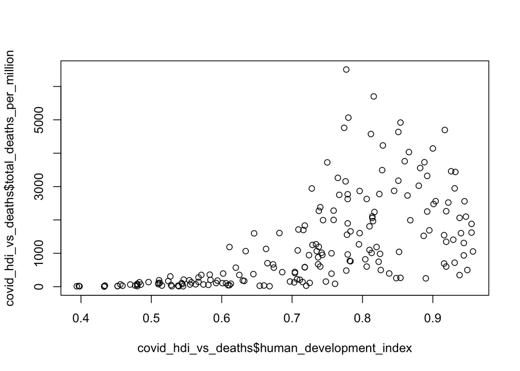

```r
# Enter your code here:
plot(covid_hdi_vs_deaths$human_development_index, covid_hdi_vs_deaths$total_deaths_per_million)
```

- Calculate the Pearson and Spearman correlation between HDI and the total deaths per million

```r
# Enter your code here:
cor.test(covid_hdi_vs_deaths$human_development_index, covid_hdi_vs_deaths$total_deaths_per_million, method = "pearson")
```

```
##
##  Pearson's product-moment correlation
##
## data:  covid_hdi_vs_deaths$human_development_index and covid_hdi_vs_deaths$total_deaths_per_million
## t = 10.234, df = 186, p-value < 2.2e-16
## alternative hypothesis: true correlation is not equal to 0
## 95 percent confidence interval:
##  0.5000520 0.6845221
## sample estimates:
##       cor
## 0.6002097
```

```r
cor.test(covid_hdi_vs_deaths$human_development_index, covid_hdi_vs_deaths$total_deaths_per_million, method = "spearman")
```

```
##
##  Spearman's rank correlation rho
##
## data:  covid_hdi_vs_deaths$human_development_index and covid_hdi_vs_deaths$total_deaths_per_million
## S = 274279, p-value < 2.2e-16
## alternative hypothesis: true rho is not equal to 0
## sample estimates:
##       rho
## 0.7523251
```

- Report the Spearman correlation coefficient, the strength of the correlation (weak/moderate/strong/very strong) and the direction (negative/positive)

[output not shown]

- Do you agree with the claim that increased in HDI causes high COVID-19 mortality? (write in detail)

```
Type your answer here:
statistically speaking, citizens of higher HDI countries are more likely to die from COVID-19.
but, statsits can only describe correlation and not causation,
we cannot infer a causative relation between higher HDI and COVID mortality.
domain knowladge can be used to match the statsics with a causative mechanism, which might involve additional variables.
```

- Find another feature in “covid_world” that explain the correlation between HDI and COVID-19 mortality
- Hint: you already have the answer in the first part of the task

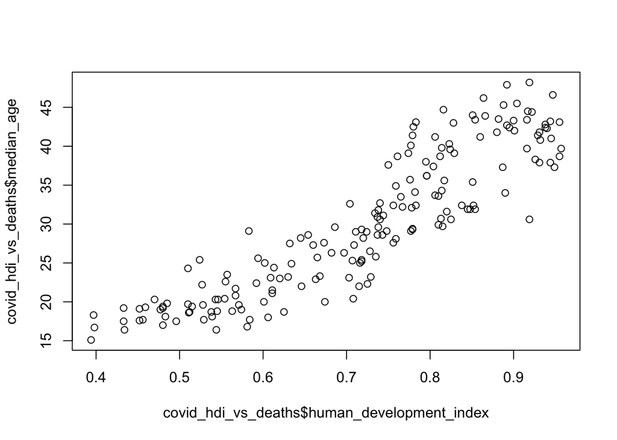

```r
# Enter your code here:
 covid_world %>%
            subset(., date == "2024-01-21") %>%
            select(.,location, human_development_index, population, total_deaths, median_age) %>%
            drop_na(.,) -> covid_hdi_vs_deaths

covid_hdi_vs_deaths$total_deaths_per_million <- round(1e6*covid_hdi_vs_deaths$total_deaths/covid_hdi_vs_deaths$population)

plot(covid_hdi_vs_deaths$human_development_index, covid_hdi_vs_deaths$median_age)
```

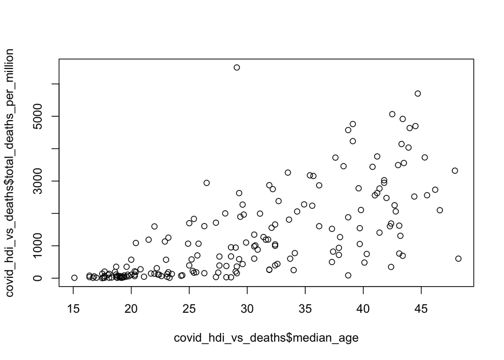

```r
plot(covid_hdi_vs_deaths$median_age, covid_hdi_vs_deaths$total_deaths_per_million)
```

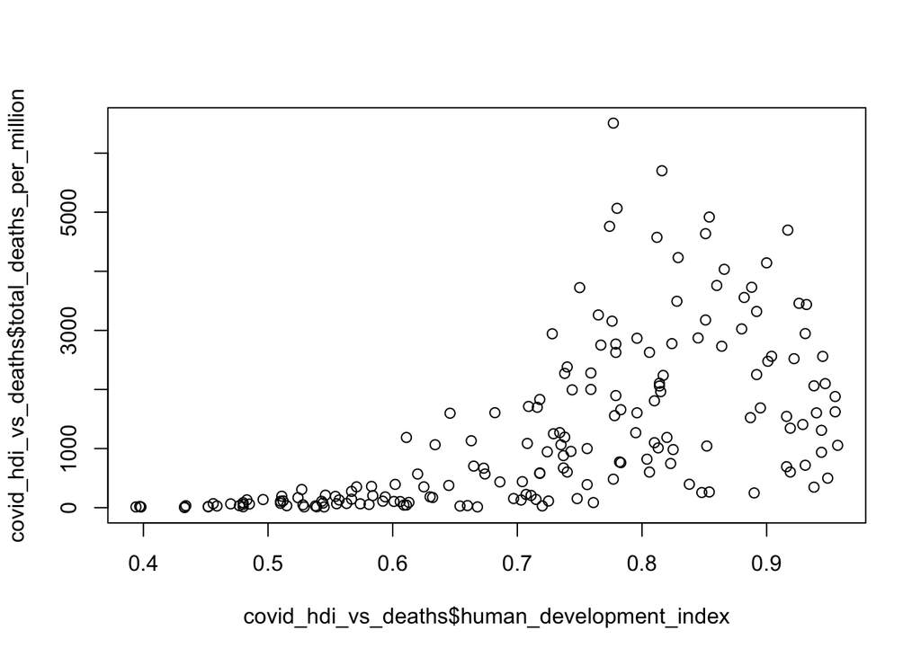

```r
plot(covid_hdi_vs_deaths$human_development_index, covid_hdi_vs_deaths$total_deaths_per_million)
```

```r
cor.test(covid_hdi_vs_deaths$human_development_index, covid_hdi_vs_deaths$median_age, method = "pearson")
```

```
##
##  Pearson's product-moment correlation
##
## data:  covid_hdi_vs_deaths$human_development_index and covid_hdi_vs_deaths$median_age
## t = 27.143, df = 180, p-value < 2.2e-16
## alternative hypothesis: true correlation is not equal to 0
## 95 percent confidence interval:
##  0.8636269 0.9217335
## sample estimates:
##       cor
## 0.8964687
```

```r
cor.test(covid_hdi_vs_deaths$median_age, covid_hdi_vs_deaths$total_deaths_per_million, method = "pearson")
```

```
##
##  Pearson's product-moment correlation
##
## data:  covid_hdi_vs_deaths$median_age and covid_hdi_vs_deaths$total_deaths_per_million
## t = 12.633, df = 180, p-value < 2.2e-16
## alternative hypothesis: true correlation is not equal to 0
## 95 percent confidence interval:
##  0.5999055 0.7556467
## sample estimates:
##      cor
## 0.685541
```

```
Write your explanation here:
we know that COVID-19 is more dangerous to older people.
we can see that HDI is very strongly correlated with median age, and that
median age is strongly correlated with mortality.
thus we can claim that the older population in higher HDI countries is more
vulnurable to COVID.
```

## Task 4 - Sequence Alignment

- Take a look at the “Biostrings” package vignettes

```r
browseVignettes("Biostrings")
```

```
## starting httpd help server ... done
```

- Read the file “covid_spike_variants.fasta” This file contain the amino acids sequence of the COVID-19 spike protein from different variants
- Read the file using the correct function from the package “Biostrings” and assign to a variable called “variants”

```r
# Enter your code here:
variants <- readAAStringSet("covid_spike_variants.fasta")
variants
```

```
## AAStringSet object of length 6:
##     width seq                                               names
## [1]  1273 MFVFLVLLPLVSSQCVNLTTRTQ...GSCCKFDEDDSEPVLKGVKLHYT 19A_China_Dec19
## [2]  1270 MFVFLVLLPLVSSQCVNLTTRTQ...GSCCKFDEDDSEPVLKGVKLHYT Alpha_UK_Sep20
## [3]  1270 MFVFLVLLPLVSSQCVNLTTRTQ...GSCCKFDEDDSEPVLKGVKLHYT Beta_SouthAfrica_...
## [4]  1273 MFVFLVLLPLVSSQCVNFTNRTQ...GSCCKFDEDDSEPVLKGVKLHYT Gamma_Brazil_Jul20
## [5]  1271 MFVFLVLLPLVSSQCVNLRTRTQ...GSCCKFDEDDSEPVLKGVKLHYT Delta_India_Dec20
## [6]  1273 MFVFLVLLPLVSIQCVNLTTRTQ...GSCCKFDEDDSEPVLKGVKLHYT Epsilon_USA_Sep20
```

- How many amino acids are in the Alpha variant?

```
Type your answer here:
1270
```

- Read the documentation for the Multiple Sequence Alignment (msa) function from the package “msa”

```r
?msa()
```

- Run MSA for the sequences in “variants” and assign the results to “variants.msa”

```r
# Enter your code here:
variants.msa <- msa(variants, type = "protein")
```

```
## use default substitution matrix
```

- Take a look at the results using the package “msaR” (notice: you can scroll right and left to see all the sequence)

```r
msaR(AAMultipleAlignment(variants.msa), colorscheme = "taylor")
```

[interactive chart not shown]

- 1. Which amino-acids appear in position #13? (type “AMINO_ACID_CODE” in the console)
- 2. Write an example of a SNP that can cause the change in amino acid as we see in the Epsilon variant

```
Type your answer here:
(1) Serine, except for Epsilon variant, in which it's Isoleucine.
(2) G to U
    ref: [Ile: AUU, AUC, AUA , Ser: UCU, UCC, UCA, UCG; AGU, AGC]
```

Phylogenetic tree for the COVID19 variants: - Use the package “seqinr” to generate a distance matrix from the MSA results and save it in a variable called “distMat”

```r
# Enter your code here:
distMat <- dist.alignment(msaConvert(variants.msa, type="seqinr::alignment"), "identity")
distMat
```

```
##                        Delta_India_Dec20 Epsilon_USA_Sep20 19A_China_Dec19
## Epsilon_USA_Sep20             0.07933635
## 19A_China_Dec19               0.07933635        0.05605519
## Alpha_UK_Sep20                0.09728167        0.08418203      0.07424157
## Beta_SouthAfrica_Aug20        0.10125397        0.08418203      0.07424157
## Gamma_Brazil_Jul20            0.11900453        0.10486965      0.09709043
##                        Alpha_UK_Sep20 Beta_SouthAfrica_Aug20
## Epsilon_USA_Sep20
## 19A_China_Dec19
## Alpha_UK_Sep20
## Beta_SouthAfrica_Aug20     0.08884064
## Gamma_Brazil_Jul20         0.10867853             0.09720504
```

- Use the package “ape” to apply “neighbor-joining” (nj) clustering algorithm to construct a phylogenetic tree
- Save the results in a variable called “ptree”

```r
# Enter your code here:
ptree <- nj(distMat)
```

- Look at the phylogenetic tree and answer the following questions:

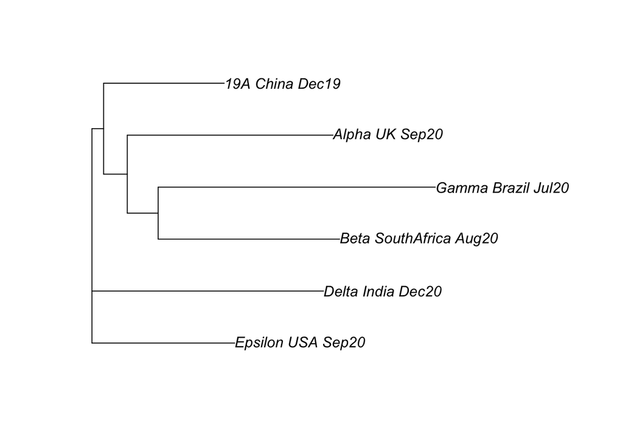

```r
ape::plot.phylo(ptree)
```

- 1. Which variant is the closest to Gamma?
- 2. Which pair seems to emerged from the Alpha variant?
     1. Epsilon and Delta
     2. Beta and Gamma
     3. Epsilon and Delta

[output not shown]

- Save this R Markdown as HTML before submitting
1. Go to “Knit” > “Knit to HTML”
2. Change the file name to your IDs (i.e, “123456789_123456789.html”)